César Alcívar

11/21/2021

```r
if(!require("tidyverse")) install.packages("tidyverse")
library(tidyverse)
```

# 1 Lectura del fichero y preparación de los datos

Cargamos el fichero `train_clean2.csv` en la variable `claim`.

```r
claim = read.csv('../R/train_clean2.csv')
summary(claim)
```

```
##        X         ClaimNumber        DateTimeOfAccident DateReported
##  Min.   :    1   Length:50526       Length:50526       Length:50526
##  1st Qu.:13515   Class :character   Class :character   Class :character
##  Median :27007   Mode  :character   Mode  :character   Mode  :character
##  Mean   :27004
##  3rd Qu.:40480
##  Max.   :54000
##       Age           Gender          MaritalStatus      DependentChildren
##  Min.   :13.00   Length:50526       Length:50526       Min.   :0.000
##  1st Qu.:24.00   Class :character   Class :character   1st Qu.:0.000
##  Median :32.00   Mode  :character   Mode  :character   Median :0.000
##  Mean   :34.04                                         Mean   :0.123
##  3rd Qu.:43.00                                         3rd Qu.:0.000
##  Max.   :81.00                                         Max.   :8.000
##  DependentsOther    WeeklyWages      PartTimeFullTime     HoursWeek
##  Min.   :0.00000   Min.   :   6.81   Length:50526       Min.   : 1.00
##  1st Qu.:0.00000   1st Qu.: 238.71   Class :character   1st Qu.:38.00
##  Median :0.00000   Median : 408.50   Mode  :character   Median :38.00
##  Mean   :0.01043   Mean   : 433.78                      Mean   :37.36
##  3rd Qu.:0.00000   3rd Qu.: 513.00                      3rd Qu.:40.00
##  Max.   :5.00000   Max.   :7497.00                      Max.   :93.00
##     DaysWeek     ClaimDescription      IniCost           UltCost
##  Min.   :1.000   Length:50526       Min.   :      1   Min.   :     6
##  1st Qu.:5.000   Class :character   1st Qu.:    735   1st Qu.:  1183
##  Median :5.000   Mode  :character   Median :   2000   Median :  3291
##  Mean   :4.906                      Mean   :   7988   Mean   : 10148
##  3rd Qu.:5.000                      3rd Qu.:   9500   3rd Qu.:  9226
##  Max.   :7.000                      Max.   :2000000   Max.   :492515
##       Time
##  Min.   :   0.00
##  1st Qu.:  14.00
##  Median :  22.00
##  Mean   :  39.05
##  3rd Qu.:  41.00
##  Max.   :1095.00
```

# 2 Coste de los siniestros

## 2.1 Análisis visual

A continuación, se muestra un diagrama de caja de la variable `UltCost`.

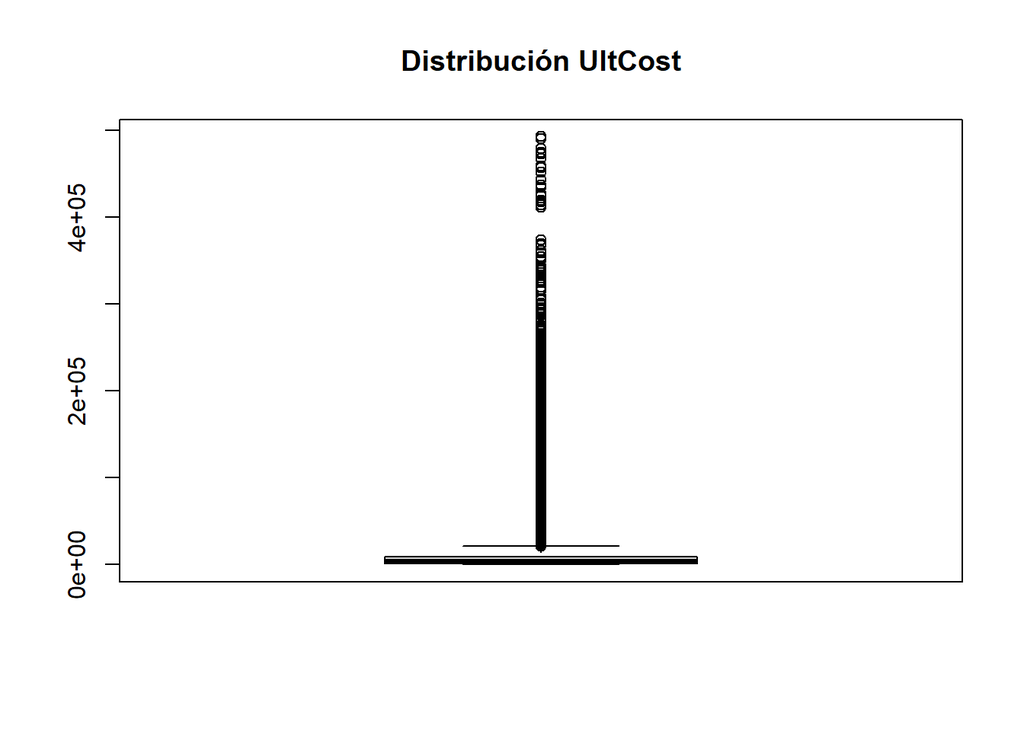

```r
boxplot(claim$UltCost, main="Distribución UltCost")
```

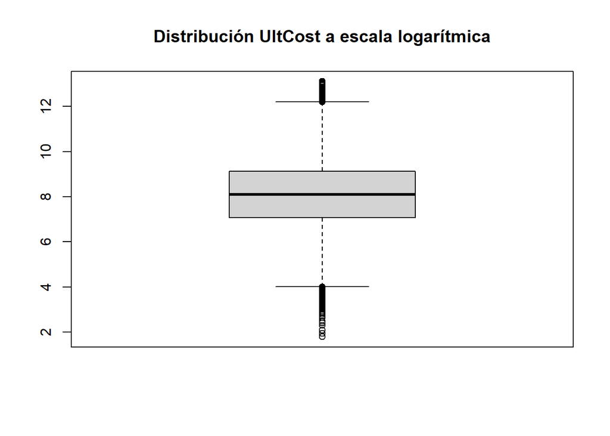

```r
boxplot(log(claim$UltCost), main="Distribución UltCost a escala logarítmica")
```

En las gráficas anteriores se observa con la función `log` los datos se vuelven más simétricos.

## 2.2 Comprobación de normalidad

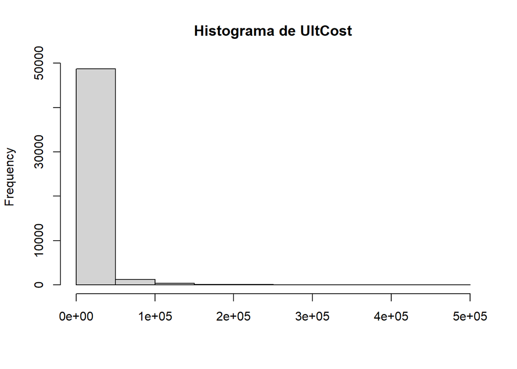

```r
hist(claim$UltCost, main = "Histograma de UltCost", xlab = "")
```

En la gráfica anterior se observa que los valores de `UltCost` no siguen una distribución normal.

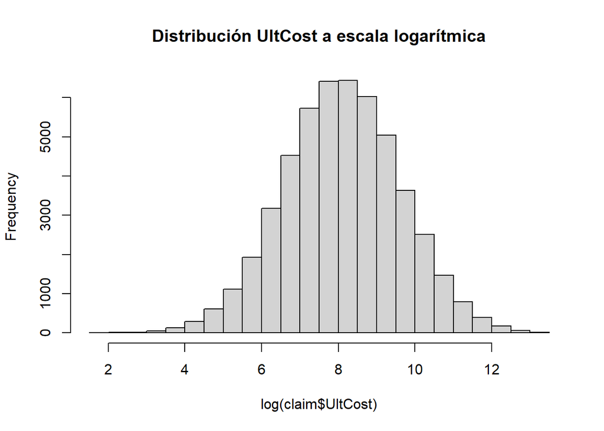

```r
hist(log(claim$UltCost), main="Distribución UltCost a escala logarítmica")
```

En la gráfica anterior se observa que aplicando la función logarítmica `log` a `UltCost` los datos se vuelven más simétricos, parecidos a una distribución normal.

```r
if(!require("nortest")) install.packages("nortest")
library(nortest)

shapiro.test(claim$UltCost[0:5000])
```

```
##
##  Shapiro-Wilk normality test
##
## data:  claim$UltCost[0:5000]
## W = 0.40808, p-value < 2.2e-16
```

Una vez realizadas las pruebas visuales y de contraste de normalidad, la muestra al ser de tamaño grande, por el teorema central del límite se establece que podemos asumir normalidad.

## 2.3 Intervalo de confianza de la media poblacional de la variable UltCost

```r
alfa <- 1-0.95
sd <- sd(claim$UltCost)
n <- nrow(claim)
SE <- sd/sqrt(n)
z <- qt(alfa/2, df=n-1, lower.tail = FALSE)
L <- mean(claim$UltCost) - z * SE
U <- mean(claim$UltCost) + z * SE
round(c(L, U), 2)
```

```
## [1]  9938.86 10356.48
```

```r
mean(claim$UltCost)
```

```
## [1] 10147.67
```

Dado que no se conoce la varianza de la población, hemos usado la distribución `t` de Student en lugar de la distribución normal para obtener el intervalo de confianza.

El intervalo de confianza obtenido está entre [9938.86, 10356.48]. La media de `Ultcost` es de 10147.67. Este valor está contenido en el intervalo de confianza, por lo tanto, concluiremos que la media de la muestra es 10147.67 con un nivel de confianza del 95%.

# 3 Coste inicial y final de los siniestros

La compañía de seguros está interesada en investigar si la estimación inicial del coste que hace de los siniestros (IniCost) en promedio es suficiente para cubrir el coste total pagado (UltCost). Por esta razón, se plantea la pregunta siguiente de investigación:

- ¿Podemos aceptar que no hay diferencias entre IniCost y UltCost?

## 3.1 Tipo de test

Se asume que la muestra sigue una distribución normal. Es un contraste de dos muestras bilateral, no se conocer la varianza de la población, por lo que, se va a realizar un test de homoscedasticidad para comprobar si son o no iguales las varianzas de IniCost y UltCost.

## 3.2 La hipótesis nula y la alternativa

La hipótesis nula es que `UltCost` y `Inicost` son iguales. La hipótesis alternativa es que `UltCost` y `Inicost` son diferentes. Si $\mu_u$ se refiere al `Ultcost` medio y $\mu_i$ al `Inicost` medio, las hipótesis nula y alternativa son:

$$\begin{matrix}
H_0: \mu_u = \mu_i \\
H_1: \mu_u \neq \mu_i
\end{matrix}$$

## 3.3 Cálculos

Nos preguntamos si `Ultcost` y `Inicost` son diferentes. Para comprobarlo realizaremos el test de igualdad de varianzas.

Las hipótesis nula y alternativa para el test de varianza son:

$$H_0: \sigma_1^2 = \sigma_2^2 \\
H_1: \sigma_1^2 \neq \sigma_2^2$$
Para realizar el test de varianza, se desarrolló la siguiente función:

```r
test_varianza = function(m1, m2) {
  alfa <- 0.05
  mean1 <- mean(m1); n1 <- length(m1); s1 <- sd(m1)
  mean2 <- mean(m2); n2 <- length(m2); s2 <- sd(m2)

  c(mean1, mean2, s1, s2, n1, n2 );

  fobs <- s1^2 / s2^2;

  fcritL <- qf(alfa/2, df1=n1-1, df2=n2-2)
  fcritU <- qf(1- alfa/2, df1=n1-1, df2=n2-2);

  pvalue <- min(pf( fobs, df1=n1-1, df2=n2-2, lower.tail=FALSE ), pf( fobs, df1=n1-1, df2=n2-2))*2;

  return (c( fobs, fcritL, fcritU, pvalue));

}
```

```r
test_varianza(claim$UltCost, claim$IniCost)
```

```
## [1]  1.343443e+00  9.827118e-01  1.017592e+00 1.488756e-240
```

Con la función `var.test` de `R` verificamos si los datos son correctos.

```r
var.test(claim$UltCost, claim$IniCost)
```

```
##
##  F test to compare two variances
##
## data:  claim$UltCost and claim$IniCost
## F = 1.3434, num df = 50525, denom df = 50525, p-value < 2.2e-16
## alternative hypothesis: true ratio of variances is not equal to 1
## 95 percent confidence interval:
##  1.320217 1.367077
## sample estimates:
## ratio of variances
##           1.343443
```

Nota: Por algún motivo que desconozco, no se están calculando correctamente los valores del intervalo de confianza. De ahora en adelante se utilizará la función `var.test` para comprobar las varianzas.

Calculamos primeramente la desviación típica común S:

$$s^2_p = \sqrt \frac{(n_1 -1)s^2_1 + (n_2 - 1)s^2_2}{n1+n2-2}$$

A continuación, se establece la ecuación de la Varianza Conjunta en código R:

```r
sd_s = function(x1, x2){
  n_1 = length(x1)
  n_2 = length(x2)
  s_1 = sd(x1)
  s_2 = sd(x2)
  return (sqrt(((n_1 -1) * (s_1^2) + (n_2 - 1) * s_2^2)/(n_1 + n_2 -2)))
}
```

El valor `t` se calcula a partir de la siguiente ecuación:

$$t = \frac{\bar{X_1} - \bar{X_2}}{S\sqrt{(\frac{1}{n_1}+ \frac{1}{n_2})}}$$

A continuación, se establece la ecuación de las Pruebas de Medias de dos Muestras $\sigma$ Disconocidas en código R:

```r
t_obs = function(x1, x2){
  s_p = sd_s(x1, x2)

  n_1 = length(x1)
  n_2 = length(x2)
  x1_mean = mean(x1)
  x2_mean = mean(x2)

  return ((x1_mean - x2_mean)/(s_p*sqrt((1/n_1)+(1/n_2))))

}
```

```r
alfa = 0.05
n_1 <- length(claim$UltCost)
n_2 <- length(claim$IniCost)

L <- qt(p=alfa/2, df=(n_1+n_2-2))
U <- qt(p=1-alfa/2, df=(n_1+n_2-2))
t_o = t_obs(claim$UltCost, claim$IniCost)

c(t_o, L, U)
```

```
## [1] 15.346482 -1.959987  1.959987
```

## 3.4 Conclusión

El estadístico `t` de 15.34 está fuera del intervalo de confianza [-1.959987, 1.959987]. Por esta razón, se rechaza la hipótesis nula, y se acepta la hipótesis alternativa.

- ¿Podemos aceptar que no hay diferencias entre IniCost y UltCost?

Se concluye que existen diferencias entre la estimación inicial del coste Coste total pagado por siniestro.

## 3.5 Comprobación

# 4 Diferencia de salario según género

Existe una opinión generalizada que las mujeres cobran menos que los hombres. Vamos a comprobar qué dicen los datos al respecto. Nos preguntamos si las mujeres reciben un menor salario (WeeklyWages) que los hombres. Se plantea la siguiente pregunta de investigación:

- ¿Podemos aceptar que los hombres cobran más que las mujeres en promedio a la semana?

```r
m_WeeklyWages = claim$WeeklyWages[claim$Gender == "M"] # dataset de hombres
f_WeeklyWages = claim$WeeklyWages[claim$Gender == "F"] # dataset de mujeres
```

## 4.1 Análisis visual

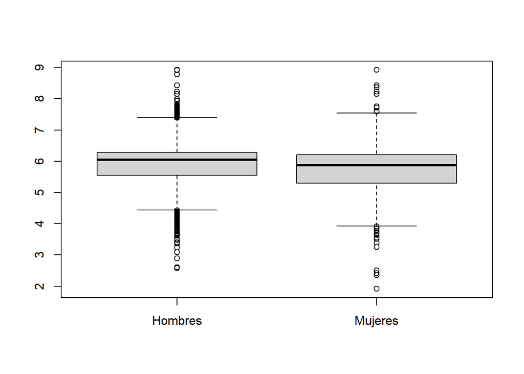

```r
boxplot(log(m_WeeklyWages), log(f_WeeklyWages), names=c("Hombres", "Mujeres"))
```

## 4.3 Hipótesis nula y alternativa

La hipótesis hula es que no hay diferencia entre los salarios de los hombres y las mujeres. La hipótesis alternativa es que el salario de los hombres es mayor que el de las mujeres. Si $\mu_s$ se refiere al salario medio de los hombres y $\mu_f$ al salario medio de las mujeres, las hipótesis nula y alternativa son:

$$\begin{matrix}
H_0: \mu_m = \mu_f \\
H_1: \mu_m > \mu_f
\end{matrix}$$

## 4.4 Tipo de test

Se asume que la muestra sigue una distribución normal. Es un contraste de dos muestras unilateral, no se conocer la varianza de la población, por lo que, se va a realizar un test de homoscedasticidad para comprobar si son o no iguales las varianzas del salario de los hombre y las mujures.

## 4.5 Cálculos

Nos preguntamos si los salario de los hombres es mayor que el de las mujeres. Para comprobarlo realizaremos el test de igualdad de varianzas.

Las hipótesis nula y alternativa para el test de varianza son:

$$H_0: \sigma_1^2 = \sigma_2^2 \\
H_1: \sigma_1^2 \neq \sigma_2^2$$

```r
var.test(m_WeeklyWages, f_WeeklyWages)
```

```
##
##  F test to compare two variances
##
## data:  m_WeeklyWages and f_WeeklyWages
## F = 1.4084, num df = 38903, denom df = 11619, p-value < 2.2e-16
## alternative hypothesis: true ratio of variances is not equal to 1
## 95 percent confidence interval:
##  1.367605 1.450156
## sample estimates:
## ratio of variances
##           1.408441
```

```r
alfa = 0.05
n_1 <- length(m_WeeklyWages)
n_2 <- length(f_WeeklyWages)

U <- qt(p=1-alfa, df=(n_1+n_2-2))
t_o = t_obs(m_WeeklyWages, f_WeeklyWages)

c(t_o, U)
```

```
## [1] 26.284427  1.644884
```

## 4.6 Conclusión

El estadístico `t` de 26.28 es mayor a 1.6448, está fuera de la zona de aceptación de la hipótesis nula. Por esta razón, se rechaza la hipótesis nula, y se acepta la hipótesis alternativa.

## 4.7 Comprobación

A continuación, se comprar el valor de t calculado con la funcion que se implemento y la función de `R`.

```r
t_r_test1 = t.test(m_WeeklyWages, f_WeeklyWages, var.equal = T)[1]
t_r_test2 = t_obs(m_WeeklyWages, f_WeeklyWages)
c(t_r_test1, t_r_test2)
```

```
## $statistic
##        t
## 26.28443
##
## [[2]]
## [1] 26.28443
```

Se verifica que el valor estadístico de `t` que son iguales que los valores.

# 5 Salario semanal

# 6 Diferencia de jornada según género

Existe una opinión generalizada que las mujeres tienden a utilizar más la jornada a tiempo parcial. Vamos a comprobar qué dicen los datos al respecto. Se plantea la siguiente pregunta de investigación:

¿La proporción de personas que trabajan a tiempo completo es diferente para hombres que para mujeres?

## 6.1 Análisis visual

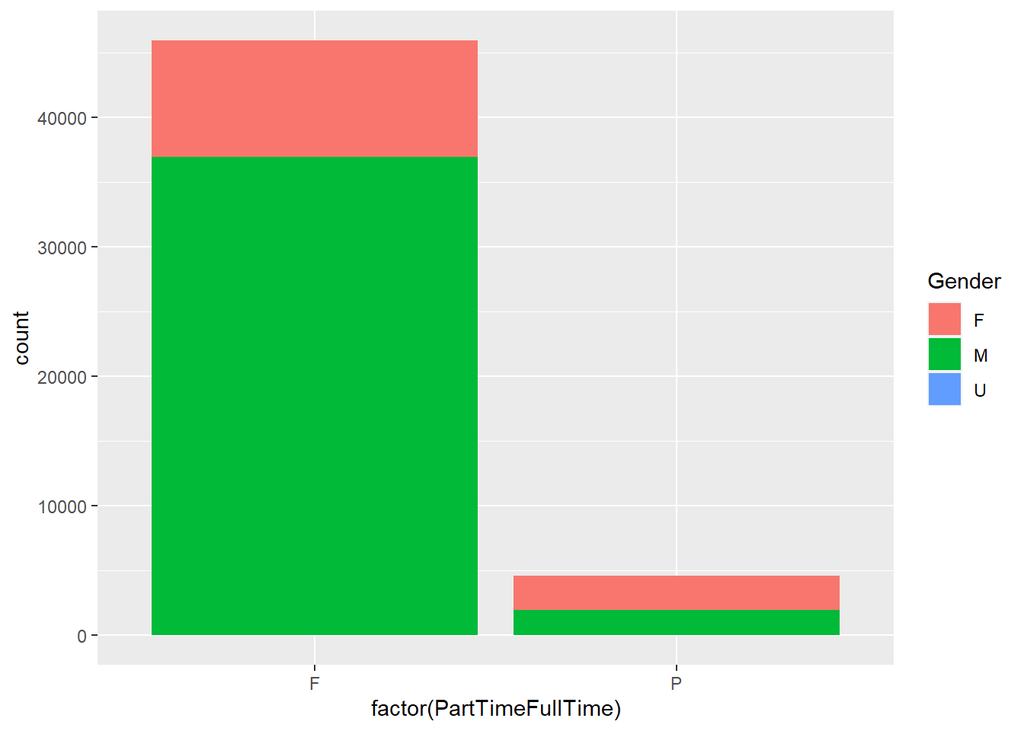

```r
# total_partime = claim[claim$PartTimeFullTime == "F" & claim$PartTimeFullTime != "U", ]
# barplot(prop.table(table(total_partime$Gender)))

ggplot(claim, aes(factor(PartTimeFullTime), fill = Gender), labels=ages.lables) + geom_bar()
```

## 6.2 Interpretación

En la gráfica anterior, se puede observar que los hombres tienen más trabajos a tiempo completo que las mujeres, y que las mujeres tienen un poco más trabajos a tiempo parcial que los hombres.

## 6.3 Hipótesis nula y alternativa

La hipótesis nula es que las mujeres y los hombres utilizan la jornada a tiempo parcial de igual forma. La La hipótesis alternativa es que las mujeres y los hombres utilizan la jornada a tiempo parcial diferentes.

$$H_0: p_f = p_m \\
H_1: p_f \neq \ p_m$$
## Tipo de test

El tipo de test que se va a realizar es un contraste de dos muestras sobre la proporción de tipo bilaterla.

## 6.4 Cálculos

```r
alfa = 0.05
total_parfulltime = claim[claim$PartTimeFullTime == 'F',] # tiempo complete
x1 <- total_parfulltime[total_parfulltime$Gender == 'M', ] # hombres tiempo completo
x2 <- total_parfulltime[total_parfulltime$Gender == 'F', ] # mujeres tiempo completo

n1 = nrow(x1)
n2 = nrow(x2)

p1 <- nrow(x1)/nrow(total_parfulltime)
p2 <- nrow(x2)/nrow(total_parfulltime)

p<-(n1*p1 + n2*p2) / (n1+n2)
zobs <- (p1-p2)/( sqrt(p*(1-p)*(1/n1+1/n2)) )

U <- qnorm(p=1-alfa/2, lower.tail=FALSE)
L <- qnorm(p=alfa/2, lower.tail=FALSE)
c(zobs, L, U)
```

```
## [1] 111.319162   1.959964  -1.959964
```

## 6.5 Conclusión

El estadistico `z` esta fuera del intervalo de confiaza, por lo que se descarta la hipotesis nula, y se acepta la hipotesis alternativa.

- ¿La proporción de personas que trabajan a tiempo completo es diferente para hombres que para mujeres?

Se concluye que la proporción de trabajos a tiempo parcial es diferente para los hombres y para las mujeres.

## 6.6 Comprobación

```r
success<-c( p1*n1, p2*n2)
nn<-c(n1,n2)

prop.test(success, nn, alternative="two.sided", correct=FALSE)
```

```
##
##  2-sample test for equality of proportions without continuity
##  correction
##
## data:  success out of nn
## X-squared = 12392, df = 1, p-value < 2.2e-16
## alternative hypothesis: two.sided
## 95 percent confidence interval:
##  0.5988588 0.6171520
## sample estimates:
##    prop 1    prop 2
## 0.8039809 0.1959755
```

# 7 Salario por hora

Anteriormente hemos comparado el salario semanal entre hombres y mujeres. Ahora bien, la pregunta que nos hacemos ahora es:

- ¿Podemos afirmar que los hombres cobran más que las mujeres por hora trabajada?

## 7.1 Tipo de test

Se asume que la muestra sigue una distribución normal. Es un contraste de dos muestras unilateral, no se conocer la varianza de la población, por lo que, se va a realizar un test de homoscedasticidad para comprobar si son o no iguales las varianzas del salario de los hombre y las mujures.

## 7.2 Cálculos

```r
claim$Hoursworked = claim$WeeklyWages/claim$HoursWeek # Valor por hora
m_WeeklyWages = claim$Hoursworked[claim$Gender == "M"] # dataset de hombres
f_WeeklyWages = claim$Hoursworked[claim$Gender == "F"] # dataset de mujeres

var.test(m_WeeklyWages, f_WeeklyWages)
```

```
##
##  F test to compare two variances
##
## data:  m_WeeklyWages and f_WeeklyWages
## F = 0.624, num df = 38903, denom df = 11619, p-value < 2.2e-16
## alternative hypothesis: true ratio of variances is not equal to 1
## 95 percent confidence interval:
##  0.6059053 0.6424789
## sample estimates:
## ratio of variances
##          0.6239975
```

```r
alfa = 0.05
n_1 <- length(m_WeeklyWages)
n_2 <- length(f_WeeklyWages)

U <- qt(p=1-alfa, df=(n_1+n_2-2))
t_o = t_obs(m_WeeklyWages, f_WeeklyWages)

c(t_o, U)
```

```
## [1] 0.8049239 1.6448838
```

## 7.3 Conclusión

El estadístico `t` de 0.8049239 es menor que 1.6448838, está dentro de la zona de aceptación de la hipótesis nula. Por esta razón, se acepta la hipótesis nula, y se rechaza la hipótesis alternativa.

- ¿Podemos afirmar que los hombres cobran más que las mujeres por hora trabajada?

Se concluye que el valor por hora de trabajo de los hombres es igual al valor de trabajo de las mujeres.

## 7.4 Comprobación

A continuación se comprar el valor de t calculado con la funcion que se implemento y la función de `R`.

```r
t_r_test1 = t.test(m_WeeklyWages, f_WeeklyWages, var.equal = T)[1]
t_r_test2 = t_obs(m_WeeklyWages, f_WeeklyWages)
c(t_r_test1, t_r_test2)
```

```
## $statistic
##         t
## 0.8049239
##
## [[2]]
## [1] 0.8049239
```

Se verifica que el valor estadistico de `t` que son iguales que los valores.

# 8 Resumen ejecutivo

- La media del Coste total pagado por siniestro de la muestra esta dentro del intervalo de confianza del 95%.
- Existen diferencias entre la estimación inicial del coste Coste total pagado por siniestro.
- El salario de los hombre es mayor que el de las mujeres.
- El porcentaje de hombres que trabajan a tiempo parcial es diferente al porcentaje de mujeres que trabajan a tiempo parcial.
- El valor por hora de trabajo de los hombres es igual al valor de trabajo de las mujeres.